# Power-analysis

Data is obtained from the supplementary material of [Kormann et al.](https://doi.org/10.1002/eap.2441) (2021), can be found here. The values do not stand for actual values of species richness, they are the estimated coeficients from linear mixed model outputs. SDs are calculated by dividing the difference between coef estimates and lower/upper 95% CI limits by 1.96.

Detailed code used for analysis is here.

## Question1: Post-hoc power calculation

Detailed results see here.

## Question2: Minimum sample size required for 80% power

- Woody, Light ~ Control

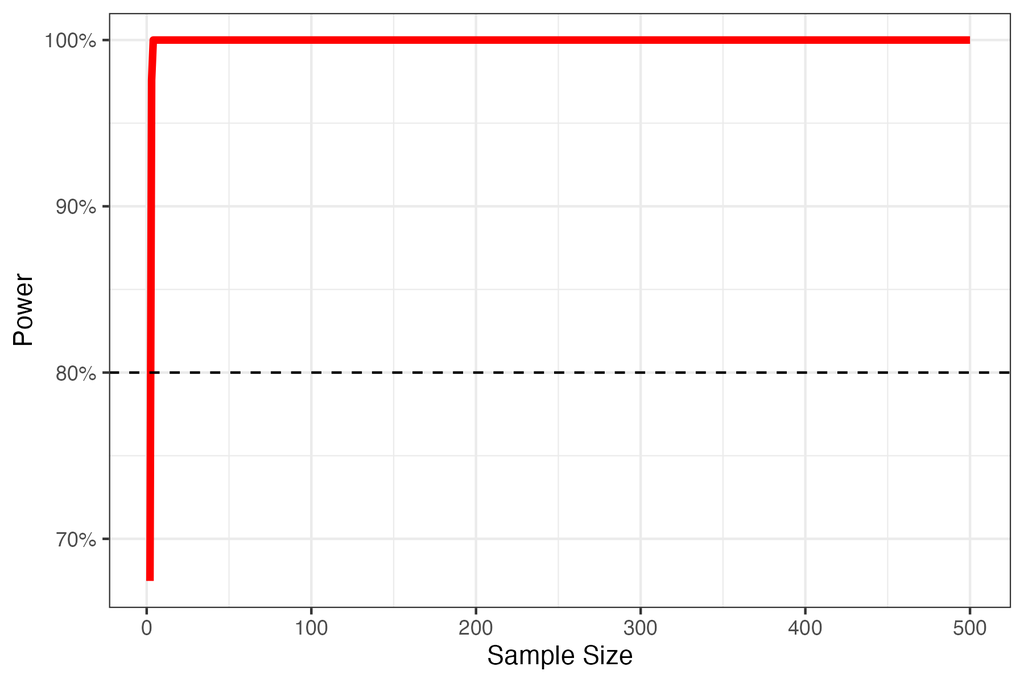

Woody, Light Group versus Control

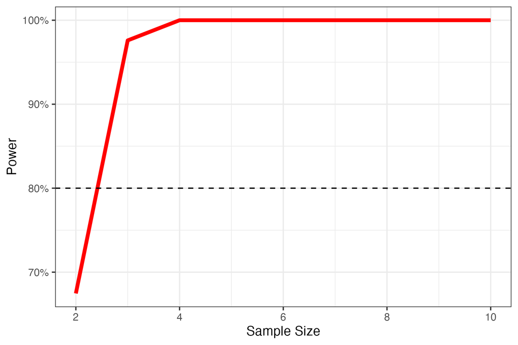

Zoom in plot

Detailed data form can be found here. Minimum sample size (#Blocks) is **3**.

- Woody, Moderate ~ Control

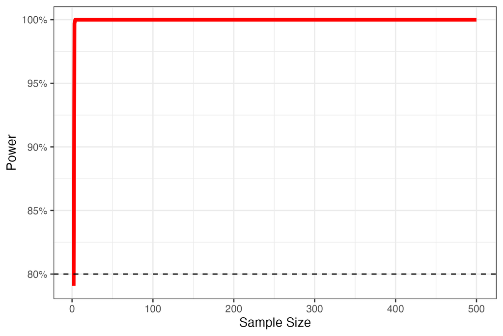

Woody, Moderate Group versus Control

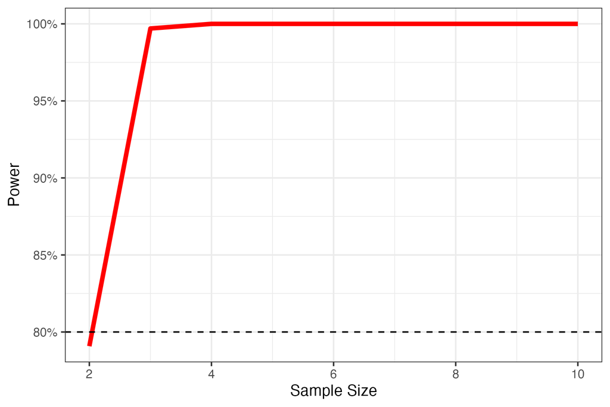

Zoom in plot

Detailed data form can be found here. Minimum sample size (#Blocks) is **3**.

- Woody, Intensive ~ Control

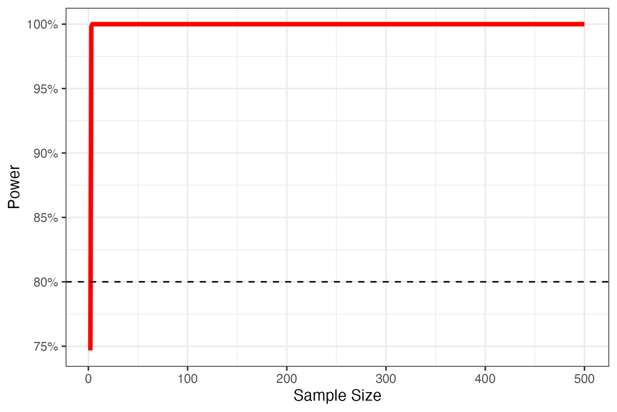

Woody, Intensive Group versus Control

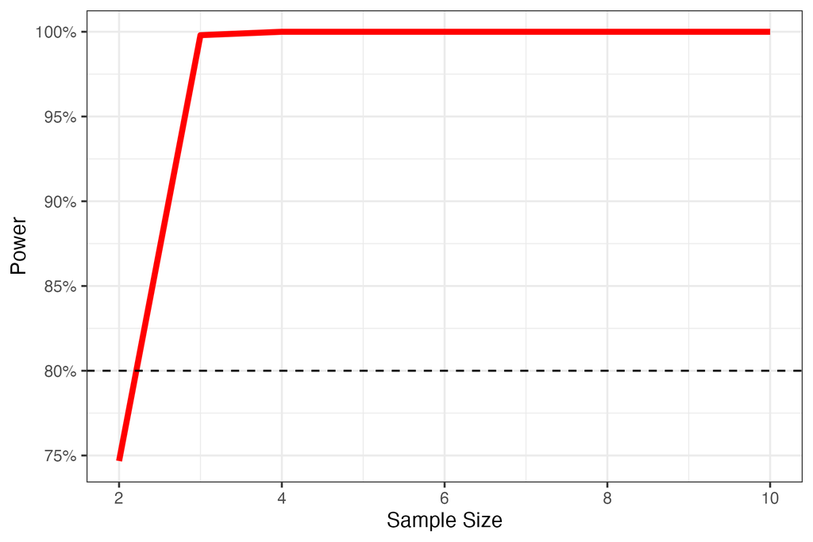

Zoom in plot

Detailed data form can be found here. Minimum sample size (#Blocks) is **3**.

- Flower, Light ~ Control

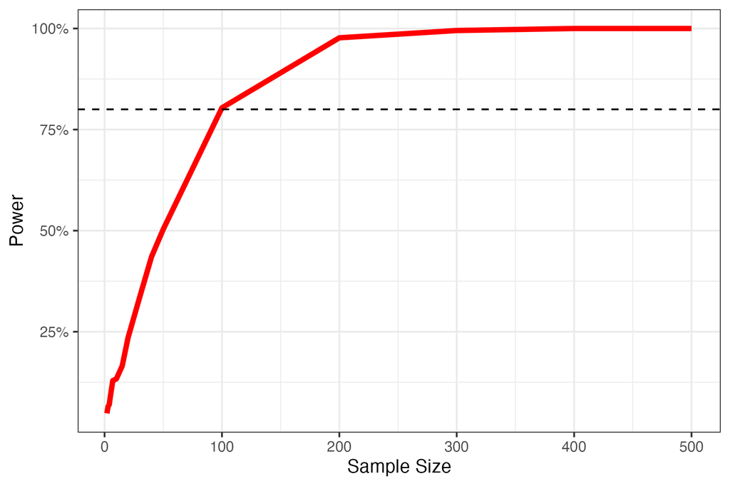

Flower, Light Group versus Control

Detailed data form can be found here.

For further settling the exact value, I rerun the sample size from 90 to 110 one by one. Detailed data form can be found here. Minimum sample size (#Blocks) is **101**. Zoom-in plot shown below:

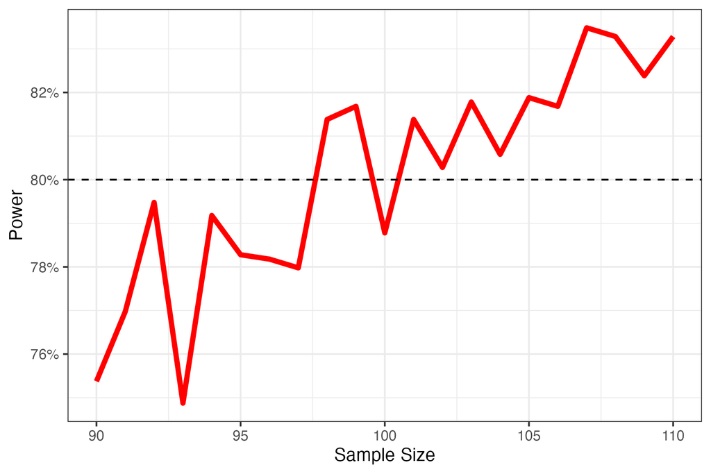

Flower, Light Group, Zoom-in

- Flower, Moderate ~ Control

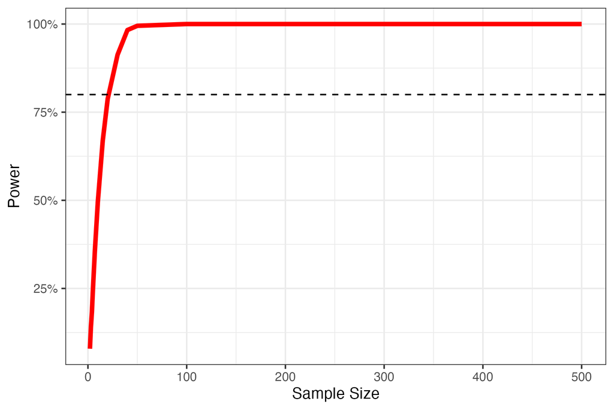

Flower, Moderate Group versus Control

Detailed data form can be found here.

For further settling the exact value, I rerun the sample size from 20 to 40 one by one. Detailed data form can be found here. Minimum sample size (#Blocks) is **22**. Zoom-in plot shown below:

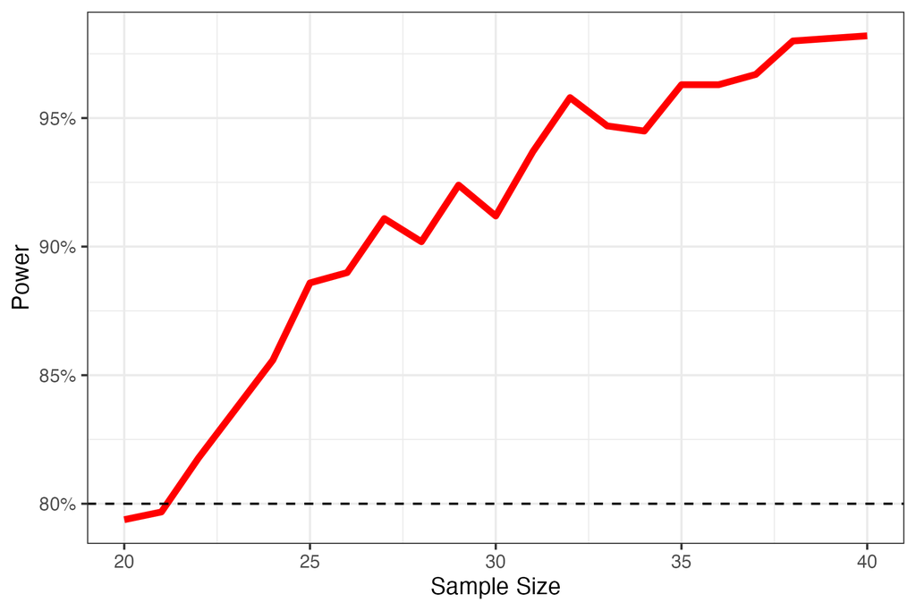

Flower, Moderate Group, Zoom-in

- Flower, Intensive ~ Control

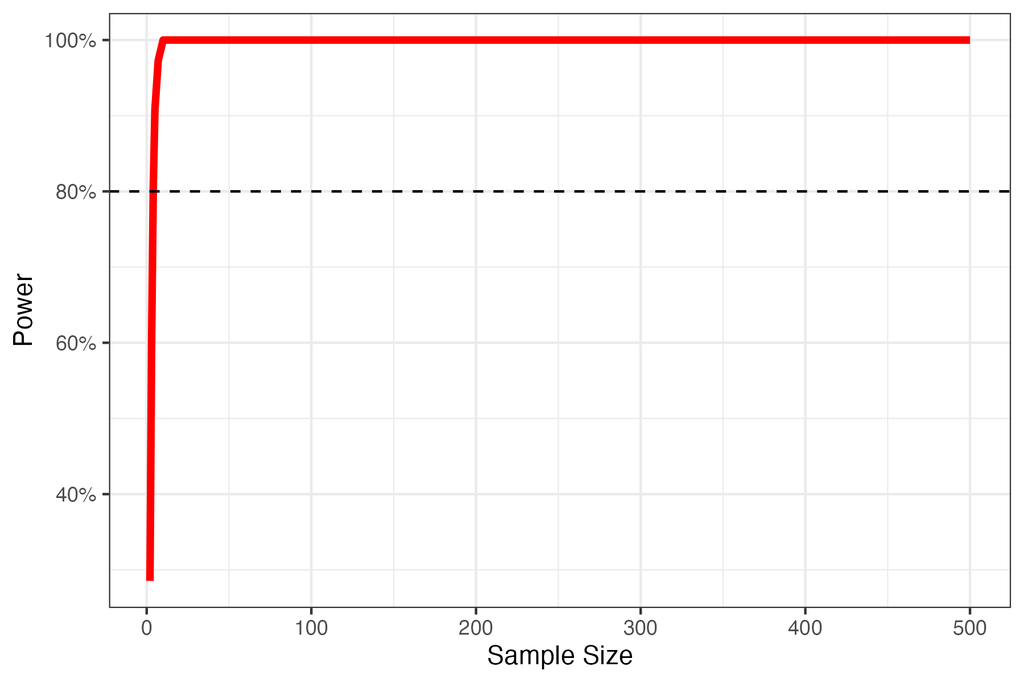

Flower, Intensive Group versus Control

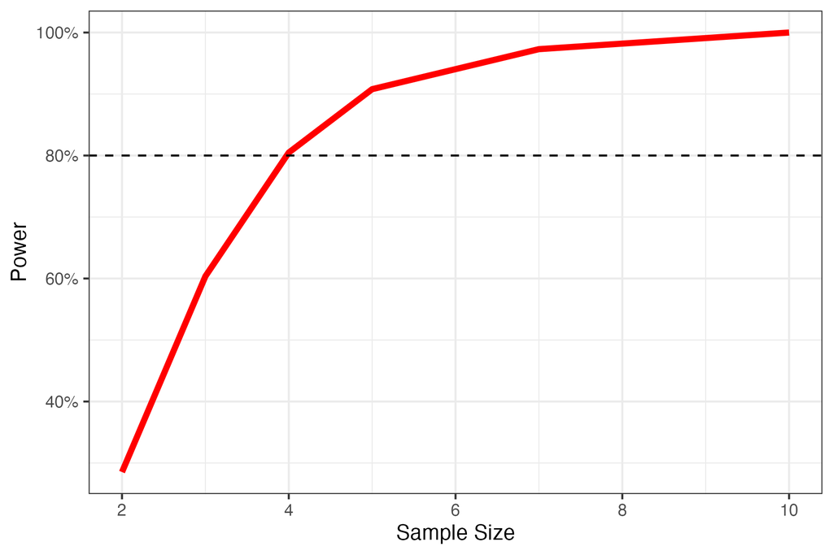

Zoom in plot

Detailed data form can be found here. Minimum sample size (#Blocks) is **4**.